# Exercícios Computacionais

Guilherme Pazian

15 de março de 2018

# 2

### (referente à série $A_{10}$:Índice de Custo de Vida no Município de São Paulo; observações mensais de janeiro de 1970 a junho de 1980)

```r
M_ICV <- read.csv("ICV.csv")
head(M_ICV)
```

```
##   Mes.ano  ICV
## 1   01/70 71,6
## 2   02/70 72,5
## 3   03/70 73,5
## 4   04/70 74,5
## 5   05/70 75,2
## 6   06/70 76,3
```

```r
ts_M_ICV <- ts(M_ICV$ICV,start = 1970,frequency = 12)
work <- "ts_M_ICV"
print(ts_M_ICV)
```

```
##      Jan Feb Mar Apr May Jun Jul Aug Sep Oct Nov Dec
## 1970  96  97  98 100 102 103 104 106 107 108 109 111
## 1971 112 115 116 117 118 119 121 122 123 124 126   1
## 1972   2   3   4   6   7   8  10  11  13  14  15  16
## 1973  17  19  20  22  23  24  25  26  27  29  30  31
## 1974  32  34  35  36  37  38  39  40  41  42  43  44
## 1975  45  46  47  48  49  50  51  52  53  54  55  56
## 1976  57  58  59  60  61  62  63  64  65  66  67  68
## 1977  69  70  71  72  73  74  75  76  77  78  79  80
## 1978  81  82  83  84  85  86  87  88  89  90  91  92
## 1979  93  94  95  99 101 105 110 113 114 120 125   5
## 1980   9  12  18  21  28  33
```

## a)

Não

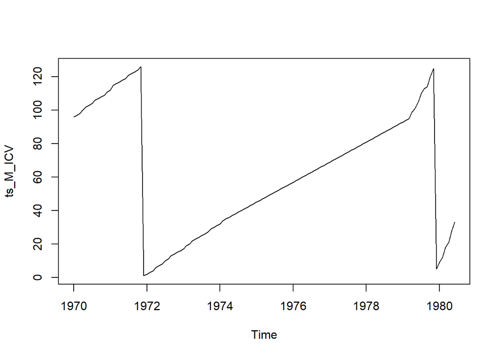

```r
ts.plot(ts_M_ICV)
```

Note pelo gráfico acima que a série não é estacionária. ##b) Não

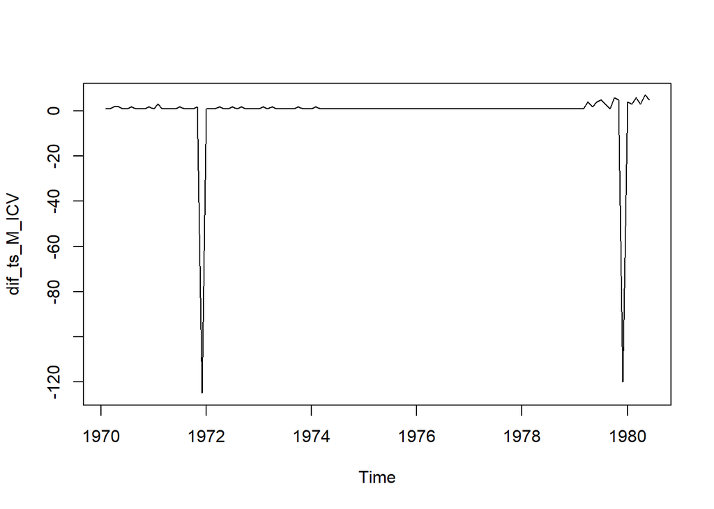

```r
#primeira diferenciação

dif_ts_M_ICV <- diff(ts_M_ICV)

ts.plot(dif_ts_M_ICV)
```

```r
append(work,"dif_ts_M_ICV")
```

```
## [1] "ts_M_ICV"     "dif_ts_M_ICV"
```

Note pelo gráfico acima que a série das diferenças de ordem 1 não é estacionária.

## c)

Não

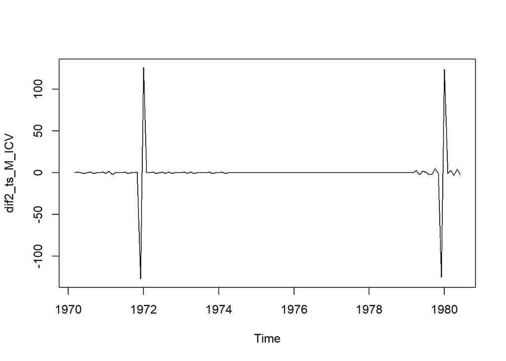

```r
#segunda diferenciação

dif2_ts_M_ICV <- diff(ts_M_ICV,differences = 2)

ts.plot(dif2_ts_M_ICV)
```

```r
append(work,"dif2_ts_M_ICV")
```

```
## [1] "ts_M_ICV"      "dif2_ts_M_ICV"
```

Note pelo gráfico acima que a série das diferenças de ordem 2 não é estacionária.

# 3

### (referente à série $A_7$ (a): Temperatura (ºC) ao meio dia, na cidade de São Paulo; observações diárias de 1ºde janeiro a 31 de dezembro de 1997)

```r
#abra o arquivo na url "https://www.ime.usp.br/~pam/temperatura.xls" o salve em formato .xls e .csv na pasta de trabalho
```

```r
atm_temp_data <- read.csv("Atmosfera.csv")
head(atm_temp_data)
```

```
##             DATA temperatura umidade
## 1 1 de jan de 97        18,4   78,58
## 2 2 de jan de 97        17,4   77,63
## 3 3 de jan de 97        17,1   78,56
## 4 4 de jan de 97        16,6   85,52
## 5 5 de jan de 97        15,8   83,36
## 6 6 de jan de 97        18,5    83,6
```

```r
nrow(atm_temp_data)
```

```
## [1] 365
```

```r
#View(atm_temp_data)
ts_atm_temp_data <- ts(atm_temp_data$temperatura,start = c(1997,1,1),frequency = 365)
work <- "atm_temp_data"
print(ts_atm_temp_data)
```

```
## Time Series:
## Start = c(1997, 1)
## End = c(1997, 365)
## Frequency = 365
##   [1]  76  66  63  59  51  77  65  79  88  83  81  88  87  89  96  87  77
##  [18]  78  70  87  86  89  86  81  81  82  78  80  88  87  87  91  86  81
##  [35]  74  82  65  79  73  77  63  66  72  62  73  82  78  64  84  75  97
##  [52]  83  92  82  85  82  65  76  65  63  47  66  54  74  74  81  72  85
##  [69]  70  80  75  76  76  75  67  60  49  53  65  61  34  38  49  61  64
##  [86]  54  30  40  24  56  68  72  73  68  42  43  38  36  44  13  17  37
## [103]  26  38  27  38  68  62  53  55  56  57  46  50  37  40  27  51  13
## [120]  37  38  38  38  60  47  32   8  40  27  42  34  31  21  24  21  18
## [137]  25  24  29  23  27  44  13  32   8   4  10  18   7   4   5 108 101
## [154] 106  19  38  35  11 100 103 111 105  39  12  38  39  15   6   2  26
## [171]  19  25  40  32  41  22  41  27  21  29  16  13  24  47  40  15  26
```

[output cut: 20 more lines]

## a)

Não

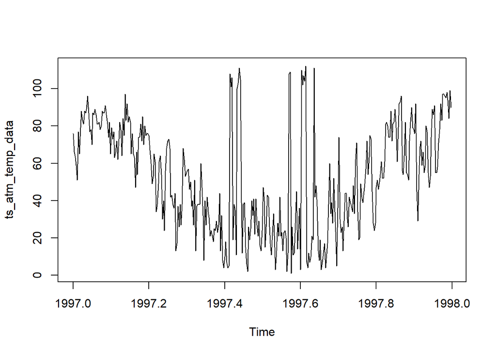

```r
ts.plot(ts_atm_temp_data)
```

Note pelo gráfico acima que a série não é estacionária. ##b) Não

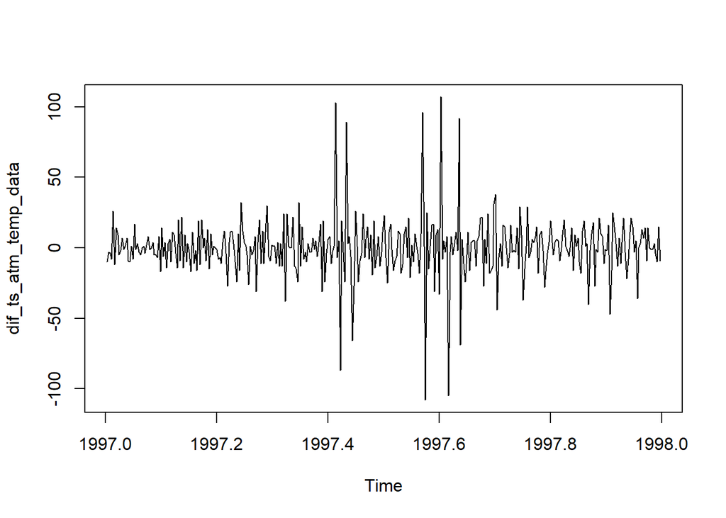

```r
#primeira diferenciação

dif_ts_atm_temp_data <- diff(ts_atm_temp_data)

ts.plot(dif_ts_atm_temp_data)
```

```r
append(work,"dif_ts_atm_temp_data")
```

```
## [1] "atm_temp_data"        "dif_ts_atm_temp_data"
```

Note pelo gráfico acima que a série das diferenças de ordem 1 embora pareça flutuar aleatóricamente ao redor de uma média (neste caso parece razoável conjecturar que $\mu$ = 0), percebemos uma diferença na variabilidade dos dados conforme o tempo, portanto a série das diferenças não parece ser estacionária.

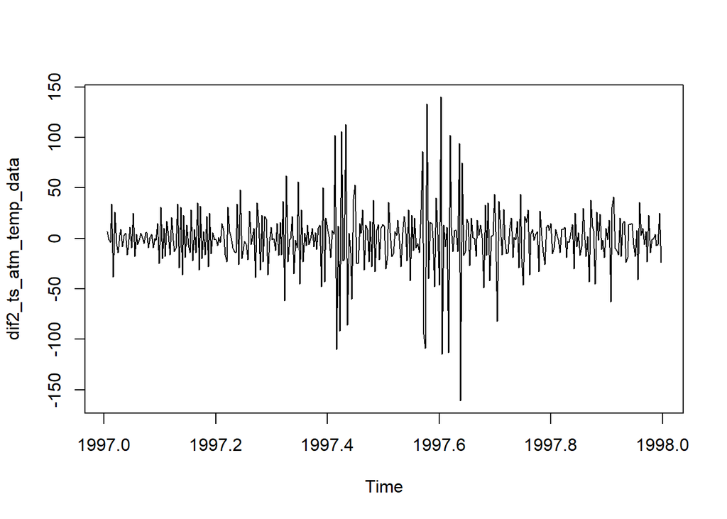

```r
#segunda diferenciação

dif2_ts_atm_temp_data <- diff(ts_atm_temp_data,differences = 2)

ts.plot(dif2_ts_atm_temp_data)
```

```r
append(work,"dif2_ts_atm_temp_data")
```

```
## [1] "atm_temp_data"         "dif2_ts_atm_temp_data"
```

Note pelo gráfico acima que a série das diferenças de ordem 2 parece não ser estacionária, uma vez que a variabilidade dos dados parece mudar ao longo do tempo. Note que o mesmo comportamento observado no gráfico das diferenças de ordem 1 estão presentes nesta série.

# 4

### (referente à série $A_{5}$ (Energia): Valores mensais do consumo de energia elétrica no estado do Espírito Santo, de janeiro de 1968 a setembro de 1979)

```r
#abra o arquivo na url "https://www.ime.usp.br/~pam/ENERGIA.XLS" o salve em formato .xls e .csv na pasta de trabalho
```

```r
energia_data <- read.csv("ENERGIA.csv")
head(energia_data)
```

```
##    Ano Mes Energia
## 1 1968   1   10951
## 2   NA   2   10671
## 3   NA   3   13643
## 4   NA   4   15109
## 5   NA   5   12602
## 6   NA   6   12295
```

```r
nrow(energia_data)
```

```
## [1] 141
```

```r
#View(atm_temp_data)
ts_energia_data <- ts(energia_data$Energia,start = c(1968,1),end = c(1979,9) ,frequency = 12)
work <- "ts_energia_data"
print(ts_energia_data)
```

```
##         Jan    Feb    Mar    Apr    May    Jun    Jul    Aug    Sep    Oct
## 1968  10951  10671  13643  15109  12602  12295  12056  12376  14146  12993
## 1969  13044  12132  13606  15876  14316  12675  14290  15170  15065  16273
## 1970  16964  17675  15548  17275  22318  21117  23326  27224  28794  19554
## 1971  29260  29591  29509  28883  32390  32702  31748  28157  32898  32909
## 1972  35105  31767  35608  35094  32674  35438  36270  35369  36742  36615
## 1973  38277  37825  34107  42106  49218  55002  51820  60111  58980  56281
## 1974  63653  65574  59721  65205  61340  59538  55018  65002  66740  63595
## 1975  65653  62089  64107  70440  65237  66885  62929  68011  71948  72940
## 1976  78868  79610  74635  80178  79802  82737  81259  81697  80502  78160
## 1977  84608  89889  81894  95400  91214  89767  89726  97896 103416 107646
## 1978 100276 118065 116504 134251 134667 144760 144438 159168 168255 175231
## 1979 179821 185780 270327 196949 202968 213178 210912 213598 210297
##         Nov    Dec
## 1968  14206  13603
## 1969  16505  16060
## 1970  19601  27330
## 1971  34087  31760
## 1972  36748  37289
## 1973  60731  62870
## 1974  63202  59822
## 1975  74873  72523
## 1976  80078  83807
## 1977 120409 109626
## 1978 174530 173720
## 1979
```

## a)

Não,sim.

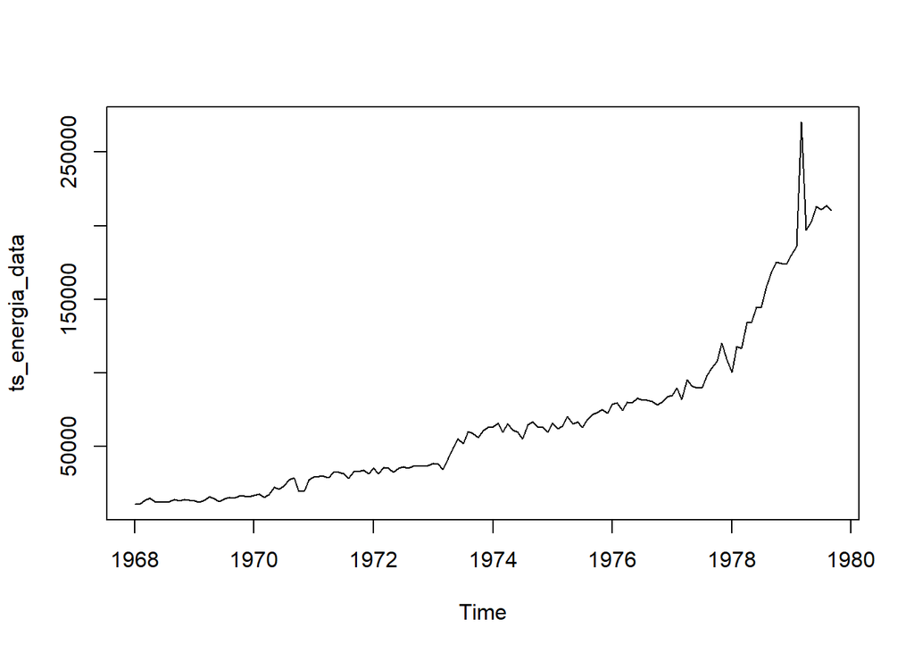

```r
ts.plot(ts_energia_data)
```

Note pelo gráfico acima que a série não é estacionária e parece apresentar uma tendencia aproximadamente exponencial positiva. ##b) Não

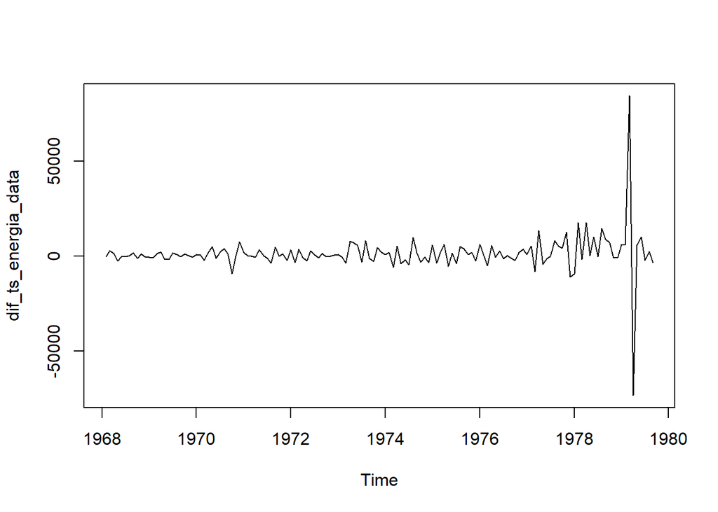

```r
#primeira diferenciação

dif_ts_energia_data <- diff(ts_energia_data)

ts.plot(dif_ts_energia_data)
```

```r
append(work,"dif_ts_energia_data")
```

```
## [1] "ts_energia_data"     "dif_ts_energia_data"
```

Note pelo gráfico acima que a série das diferenças de ordem 1 embora pareça flutuar aleatóricamente ao redor de uma média (neste caso parece razoável conjecturar que $\mu$ = 0), percebemos uma diferença na variabilidade dos dados conforme o tempo, portanto a série das diferenças não parece ser estacionária.

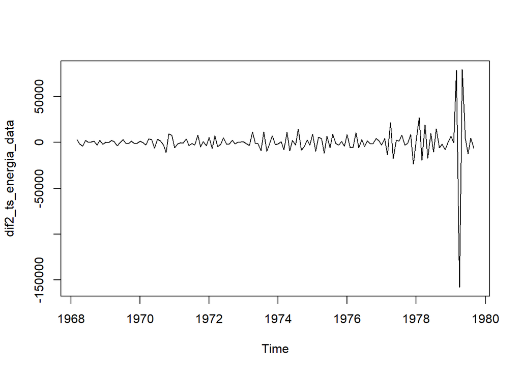

```r
#segunda diferenciação

dif2_ts_energia_data <- diff(ts_energia_data,differences = 2)

ts.plot(dif2_ts_energia_data)
```

```r
append(work,"dif2_ts_energia_data")
```

```
## [1] "ts_energia_data"      "dif2_ts_energia_data"
```

Note pelo gráfico acima que a série das diferenças de ordem 2 parece não ser estacionária, uma vez que a variabilidade dos dados parece mudar ao longo do tempo. Note que o mesmo comportamento observado no gráfico das diferenças de ordem 1 estão presentes nesta série.

## c)

Não

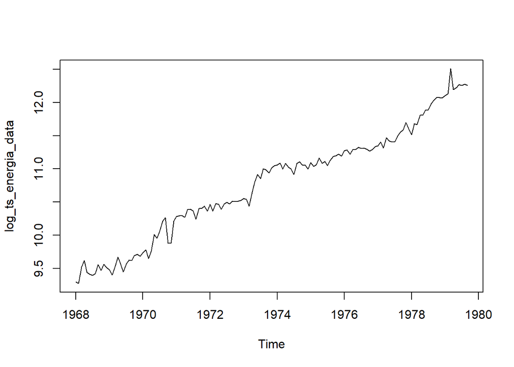

```r
log_ts_energia_data <- log(ts_energia_data)

ts.plot(log_ts_energia_data)
```

Note pelo gráfico acima que a série não é estacionária e parece apresentar uma tendencia aproximadamente linear positiva.

## d)

Não

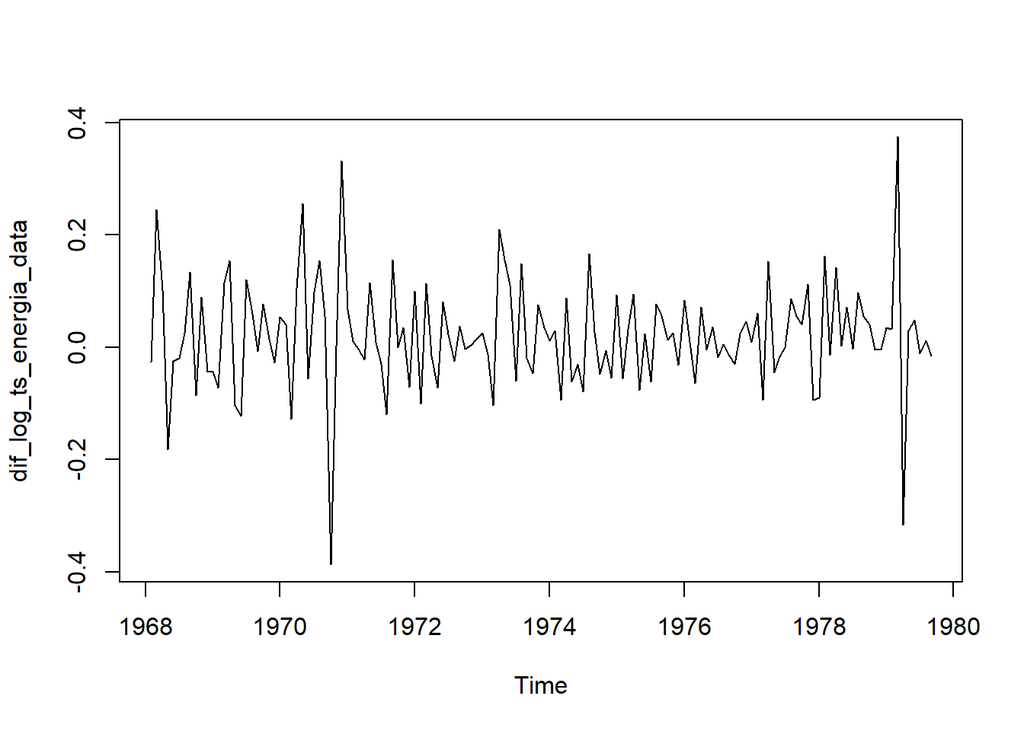

```r
dif_log_ts_energia_data <- diff(log_ts_energia_data)

ts.plot(dif_log_ts_energia_data)
```

Note pelo gráfico acima que a série das diferenças de ordem 1 do log da série “Energia” embora pareça flutuar aleatóricamente ao redor de uma média (neste caso parece razoável conjecturar que $\mu$ = 0), percebemos uma diferença na variabilidade dos dados conforme o tempo (embora seja aparententemente menor em relação à variabilidade apresentada na diferença de ordem 1 da série original), portanto a série das diferenças não parece ser estacionária.

# 5

### (referente à série $A_{9}$ (D-PETRO): Preços diários das ações da Petrobrás PN, de 03/01/1995 a 27/12/2000)

```r
#acesse os dados atravez da url "https://www.ime.usp.br/~pam/D-PETRO" copie e cole os dados em um arquivo .txt na pasta de trabalho
```

```r
D_Petro <- read.csv("D-PETRO.txt",header = FALSE)
head(D_Petro)
```

```
##         V1
## 1 8780.295
## 2 8278.564
## 3 7944.077
## 4 8027.698
## 5 7400.534
## 6 7191.480
```

```r
nrow(D_Petro)
```

```
## [1] 1499
```

```r
#View(atm_temp_data)
ts_D_Petro <- ts(D_Petro ,start = c(1995,03,01),end = c(2000,27,12) ,frequency =365)
work <- "ts_D_Petro"
print(ts_D_Petro)
```

```
## Time Series:
## Start = c(1995, 3)
## End = c(2000, 27)
## Frequency = 365
##    [1]  8780.295  8278.564  7944.077  8027.698  7400.534  7191.480
##    [7]  6438.883  6606.127  7442.345  8278.564  8069.509  8278.564
##   [13]  8027.698  7400.534  7609.589  7191.480  7358.724  7358.724
##   [19]  7902.266  7609.589  7066.047  7693.211  7944.077  7818.644
##   [25]  8111.320  7902.266  7525.967  7484.156  7107.858  7024.236
##   [31]  7358.724  7149.669  6856.992  6564.316  6940.614  6773.371
##   [37]  6273.312  6522.505  7358.724  7234.127  7234.127  6606.127
##   [43]  6564.316  6271.639  5309.988  4682.824  4264.715  5268.177
##   [49]  5059.122  5811.719  5603.501  6104.396  5978.963  5477.232
##   [55]  5686.286  5561.690  5935.480  6188.018  6071.875  5896.243
##   [61]  5728.973  5478.069  5227.165  5018.079  5728.973  5728.973
```

[output cut: 298 more lines]

## a)

Não,sim.

[figure not shown]

```r
ts.plot(ts_energia_data)
```

Note pelo gráfico acima que a série não é estacionária e parece apresentar uma tendencia aproximadamente exponencial positiva. ##b) Não

[figure not shown]

```r
#primeira diferenciação

dif_ts_energia_data <- diff(ts_energia_data)

ts.plot(dif_ts_energia_data)
```

```r
append(work,"dif_ts_energia_data")
```

```
## [1] "ts_D_Petro"          "dif_ts_energia_data"
```

Note pelo gráfico acima que a série das diferenças de ordem 1 embora pareça flutuar aleatóricamente ao redor de uma média (neste caso parece razoável conjecturar que $\mu$ = 0), percebemos uma diferença na variabilidade dos dados conforme o tempo, portanto a série das diferenças não parece ser estacionária.

[figure not shown]

```r
#segunda diferenciação

dif2_ts_energia_data <- diff(ts_energia_data,differences = 2)

ts.plot(dif2_ts_energia_data)
```

```r
append(work,"dif2_ts_energia_data")
```

```
## [1] "ts_D_Petro"           "dif2_ts_energia_data"
```

Note pelo gráfico acima que a série das diferenças de ordem 2 parece não ser estacionária, uma vez que a variabilidade dos dados parece mudar ao longo do tempo. Note que o mesmo comportamento observado no gráfico das diferenças de ordem 1 estão presentes nesta série.

## c)

Não

[figure not shown]

```r
log_ts_energia_data <- log(ts_energia_data)

ts.plot(log_ts_energia_data)
```

Note pelo gráfico acima que a série não é estacionária e parece apresentar uma tendencia aproximadamente linear positiva.

## d)

Não

[figure not shown]

```r
dif_log_ts_energia_data <- diff(log_ts_energia_data)

ts.plot(dif_log_ts_energia_data)
```